# Session1-5 for Econometrics

sn0wfree

11/12/2016

# Session1-5

## Basic Objects

### list enviornment

```r
ls()# to list the current environment
```

```
## character(0)
```

## Vector and Matrix

### Vector

to create Vector based on c() function c() function is the function to create tuple or called Vector

```r
# c():create a tuple, also can be seen a Vector if it is numberic tuple. because the tuple is the list with ordered element
nv=c(6,5,4,3,2,1)
cv=c("a string of characters","also a string of characters")
nv[3]
```

```
## [1] 4
```

```r
cv[1]
```

```
## [1] "a string of characters"
```

```r
vec=vector(mode = "list",length = 2)# in the mode, there are three options:"list", "experession" and "any"
length(nv) #show the number of elements
```

```
## [1] 6
```

```r
min(nv) #minimum value of nv
```

```
## [1] 1
```

```r
which.min(nv) #the index of the minimum value of nv
```

```
## [1] 6
```

```r
max(nv) #maximum value of nv
```

```
## [1] 6
```

```r
which.max(nv) #the index of the maximum value of nv sort(nv,decreasing=TRUE) #list nv’s elements of nv decreasingly,decreasing is an optional argument with default value FALSE
```

```
## [1] 1
```

```r
nv[2:5] #print 2-5 elements of nv
```

```
## [1] 5 4 3 2
```

the code for matrix is matrix():it look like a dataframe

```r
m1=matrix(nv,nrow=3,ncol=2)
m1
```

```
##      [,1] [,2]
## [1,]    6    3
## [2,]    5    2
## [3,]    4    1
```

```r
class(nv)#class() function is to show the class of target element, like the type function in Python
```

```
## [1] "numeric"
```

```r
class(m1)
```

```
## [1] "matrix"
```

```r
#show the dimension
attributes(nv)
```

[output not shown]

```r
attributes(m1)# show the dimension of element:(row,colmn)
```

```
## $dim
## [1] 3 2
```

```r
dim(m1)#another function can show the dimension as well:(row,colmn)
```

```
## [1] 3 2
```

```r
m1[3,2] #print the (3, 2) element of m1
```

```
## [1] 1
```

```r
m1[,2] #print the 2nd column of m1
```

```
## [1] 3 2 1
```

```r
2*m1 #scalar multiplication
```

```
##      [,1] [,2]
## [1,]   12    6
## [2,]   10    4
## [3,]    8    2
```

```r
diag(2) #identity matrix of dimension 2
```

```
##      [,1] [,2]
## [1,]    1    0
## [2,]    0    1
```

```r
rep(1,2) #replicate 1 twice,this function can create the identity matrix
```

```
## [1] 1 1
```

```r
cbind(rep(1,6),nv) #put two vectors vertically together to make a matrix
```

```
##        nv
## [1,] 1  6
## [2,] 1  5
## [3,] 1  4
## [4,] 1  3
## [5,] 1  2
## [6,] 1  1
```

```r
m3=m1%*%t(m1) #t() is to transpose a matrix and %*% is for matrix multiplication

qr(m3)#A=QR,use QR Decomposition: an orthogonal matrix Q and an upper triangular matrix R. QR decomposition is often used to solve the linear least squares problem, and is the basis for a particular eigenvalue algorithm, the QR algorithm
```

```
## $qr
##             [,1]        [,2]        [,3]
## [1,] -63.6396103 -51.1945310 -38.7494516
## [2,]   0.5656854  -0.3464102  -0.6928203
## [3,]   0.4242641   0.9517782   0.0000000
##
## $rank
## [1] 2
##
## $qraux
## [1] 1.707107 1.306787 0.000000
##
## $pivot
## [1] 1 2 3
##
## attr(,"class")
## [1] "qr"
```

```r
qr(m3)$rank #rank of m3
```

```
## [1] 2
```

```r
diag(m3)#extract the diagonal of a matrix(m3)
```

```
## [1] 45 29 17
```

```r
sum(diag(m3)) #trace of m3: the trace of an n-by-n square matrix A is defined to be the sum of the elements on the main diagonal (the diagonal from the upper left to the lower right) of A
```

```
## [1] 91
```

```r
diag(m3)<-1#replace the diagonal of matrix with 1
solve(m3) #inverse of m3
```

```
##             [,1]        [,2]        [,3]
## [1,] -0.01199702  0.01385991  0.01900149
## [2,]  0.01385991 -0.01808246  0.02359662
## [3,]  0.01900149  0.02359662 -0.03216592
```

## Infinite Values and Missing Data

the computer software exist several limit on the precision format and 32-bit/64-bit limit

```r
typeof(1.9)# another kind of class funtion with more detail in the numeric part, it categories the type of numeric with double(floating), integer number.
```

```
## [1] "double"
```

```r
as.integer(1.9)# this function transfer the 1.9(double numeric) into the integer number
```

```
## [1] 1
```

```r
is.integer(1.9)# this function judege the type of this number(a),return the pool value:(FASLE or TRUE)
```

```
## [1] FALSE
```

```r
as.integer(2^31 - 1) #transfer (2^31 - 1) into integer number ,larger than this number  can not  be calculated
```

```
## [1] 2147483647
```

```r
2^1024 #this is also too larger than the upper limits which is based on the 32-bit limit of software
```

```
## [1] Inf
```

## Probability Related Functions

```r
runif(n=10,min = 1,max = 10)# generate 10 random numbers uniformly from 1 to 10
```

```
##  [1] 3.690534 2.651997 3.808131 2.702795 5.958177 2.259991 6.102489
##  [8] 9.506942 1.117442 6.822956
```

```r
rnorm(n=10,mean=0,sd=1)# generate 10 normally distributed random numbers with mean=0 and standard deviation =1
```

```
##  [1] -1.088330043  0.157303162  0.102366581  0.258155957 -0.715292712
##  [6] -0.371214788  0.767643435 -0.706628666  0.307570935 -0.002184369
```

```r
rt(n=10,df=2) # generate 10 random numbers from student t-distribution with df=2 degress of freedom
```

```
##  [1] -0.27035773 -4.88395087  3.20648219 -0.05426061 -0.84623563
##  [6]  1.81751768 -3.06040020 -0.47200207 -2.90317704  0.89743993
```

```r
dnorm(0.005) # return the density function value of standard normal distribution evaluated at 0.005
```

```
## [1] 0.3989373
```

```r
pnorm(0.5) # return the cumulative distribution function of standard normal distribution eveluated at 0.5
```

```
## [1] 0.6914625
```

```r
qnorm(p=0.25) # return the 0.25th quantile of standard normal distribution(0<=p<=1)
```

```
## [1] -0.6744898
```

## Other Useful Objetcs

### Factor object

organize the data point into different categories.- tag as character variable retag the data point with factor tag,

```r
gender<-factor(c("male","male","male","female","female"))# create two level categories: male and female
levels(gender)# show the categories.
```

```
## [1] "female" "male"
```

### Time Series Object

use ts() function to create a special vector with a time index.

`ts(data,start=c(start-year,start-mounth),frequency)` will create a series of random normally dirtributed numbers (n=100) and order them by mounths, and start mouths is april 1987 (12 mouths as a circle; mounthly times series). if change the freq as 4, so it will create quarterly times series. other freq will not be defined as times series,but based on year.

```r
myts1=ts(data=rnorm(100),start=c(1987,4),freq = 12)#create a series of random normally dirtributed numbers (n=100) and order them by mounths, and start mouths is april 1987 (12 mouths as a circle; mounthly times series). if change the freq as 4, so it will create quarterly times series. other freq will not be defined as times series,but based on year
tsp(myts1) # return the start, end time(in numeric format) and frequency
```

```
## [1] 1987.25 1995.50   12.00
```

### List Object

use list objects(`list()`) to contain the data with different types/classes

```r
lobj<-list(name="Jack",stid=123,score=100)# create a list with different attributes,it likes the dictionary in the Python. in the list, there exist the order.
lobj$name# will print the value of name in list of lobj
```

```
## [1] "Jack"
```

```r
lobj[2]# will print the 2rd element,include the name and value
```

```
## $stid
## [1] 123
```

```r
lobj[[2]] # will print the value of 2rd element, if there not exist the name, will use the order instead, like "name" in lobj will be replace as [[1]]
```

```
## [1] 123
```

```r
lobj2 =vector(mode="list",length = 2)# in the mode, there are three options:"list", "experession" and "any"
lobj2[[1]]<-lobj # put the lobj into the 2rd element of lobj2
lobj2[[1]]<-list(name="Jack",stid=123,score=100)# equivalently lobj2[[1]]<-lobj
lobj2[[2]]<-list(name="Mike",stid=245,score=60)
lobj2[[1]]$stid # the find student's ID number
```

```
## [1] 123
```

```r
lobj2[[2]][[3]] # the second student's score
```

```
## [1] 60
```

### Dataframe Object

```r
setwd("/Users/sn0wfree/Dropbox/PhD_1st_study/BST169_Econometrics/Computing/session1-5")#setup the working directory
london<-read.csv('london.csv')# import data from london.csv
class(london)
```

```
## [1] "data.frame"
```

```r
typeof(london)
```

```
## [1] "list"
```

#### structure, head and colname

now about look the structure of data, head of data and the label or colmn’s name

```r
str(london)# show the structure of data, include the types, observation and variables
```

```
## 'data.frame':    1519 obs. of  11 variables:
##  $ X...  : int  1 2 3 4 5 6 7 8 9 10 ...
##  $ wfood : num  0.427 0.374 0.194 0.444 0.333 ...
##  $ wfuel : num  0.1342 0.1686 0.4056 0.1258 0.0824 ...
##  $ wcloth: num  0 0.0091 0.0012 0.0539 0.0399 ...
##  $ walc  : num  0.0106 0.0825 0.0513 0.0397 0.1571 ...
##  $ wtrans: num  0.1458 0.1215 0.2063 0.0652 0.2403 ...
##  $ wother: num  0.282 0.244 0.141 0.272 0.147 ...
##  $ totexp: int  50 90 180 80 90 70 140 50 100 90 ...
##  $ income: int  130 150 230 100 100 70 190 100 260 110 ...
##  $ age   : int  25 39 47 33 31 24 46 25 30 41 ...
##  $ nk    : int  2 2 2 2 1 1 1 1 1 1 ...
```

```r
head(london)# show first 6 row
```

```
##   X...  wfood  wfuel wcloth   walc wtrans wother totexp income age nk
## 1    1 0.4272 0.1342 0.0000 0.0106 0.1458 0.2822     50    130  25  2
## 2    2 0.3739 0.1686 0.0091 0.0825 0.1215 0.2444     90    150  39  2
## 3    3 0.1941 0.4056 0.0012 0.0513 0.2063 0.1415    180    230  47  2
## 4    4 0.4438 0.1258 0.0539 0.0397 0.0652 0.2716     80    100  33  2
## 5    5 0.3331 0.0824 0.0399 0.1571 0.2403 0.1473     90    100  31  1
## 6    6 0.3752 0.0481 0.1170 0.0210 0.0955 0.3431     70     70  24  1
```

```r
colnames(london)# show the label or colmn's name, also called the variables' name
```

```
##  [1] "X..."   "wfood"  "wfuel"  "wcloth" "walc"   "wtrans" "wother"
##  [8] "totexp" "income" "age"    "nk"
```

```r
london$wcloth# show the wcloth variable in the london dataset.
```

```
##    [1] 0.0000 0.0091 0.0012 0.0539 0.0399 0.1170 0.0453 0.1131 0.1671
##   [10]     NA 0.2547 0.1617 0.0018 0.0728 0.2010 0.0501 0.0722 0.0727
##   [19] 0.1511 0.0454 0.0931 0.0246 0.0506 0.1451 0.0054 0.0180 0.2388
##   [28] 0.0392 0.0788 0.3875 0.0077 0.0085 0.1310 0.1428 0.0458 0.2943
##   [37] 0.0662 0.1530 0.2702 0.1808 0.1046 0.0033 0.0058 0.0419 0.0662
##   [46] 0.0542 0.1605 0.1109 0.0000 0.0796 0.1156 0.1846 0.2889 0.1610
##   [55] 0.0928 0.2845 0.1902 0.1102 0.0517 0.1495 0.1060 0.1012 0.0254
##   [64] 0.2637 0.0155 0.0049 0.1491 0.0834 0.0098 0.1980 0.0147 0.1582
##   [73] 0.0596 0.0419 0.1914 0.0200 0.0927 0.0217 0.2294 0.0017 0.2278
##   [82] 0.1393 0.0144 0.0451 0.0000 0.0168 0.0306 0.0038 0.2158 0.1370
##   [91] 0.0717 0.0834 0.0446 0.0000 0.1680 0.0000 0.0856 0.0674 0.3036
##  [100] 0.0985 0.1172 0.0030 0.0184 0.0456 0.0693 0.1423 0.0213 0.0363
##  [109] 0.1034 0.0755 0.0000 0.1856 0.0049 0.2395 0.2728 0.0613 0.0863
##  [118] 0.1169 0.3933 0.0453 0.2002 0.1613 0.0616 0.0830 0.0623 0.0054
##  [127] 0.1744 0.1345 0.0493 0.0579 0.0545 0.2106 0.1114 0.1848 0.1940
```

[output cut: 154 more lines]

```r
london[,1]=as.character(london[,1])# reset the 1st column as.character
```

### Some Statistical Functions

Some useful Statistical Functions

```r
sum(london$income)#sum of the income of all obervations in london dataset
```

```
## [1] 206960
```

```r
mean(london$income)
```

```
## [1] 136.2475
```

```r
var(london$income)
```

```
## [1] 3728.466
```

```r
sd(london$income)
```

```
## [1] 61.06116
```

```r
quantile(london$income)
```

```
##   0%  25%  50%  75% 100%
##   20  100  120  160 1110
```

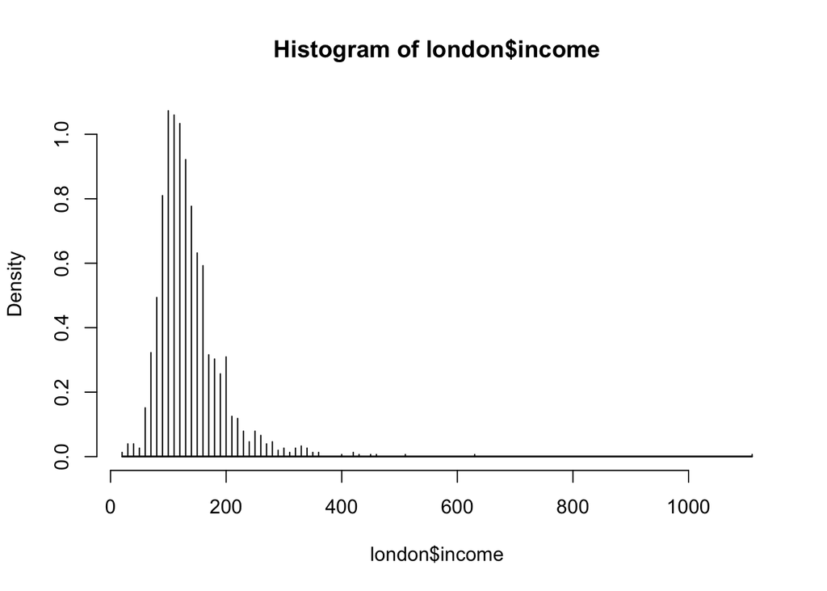

```r
hist(london$income,breaks=10000,freq = FALSE)# draw a histogram based on london$income, the breaks is the number of cells,freq: show the freqency of not, if FALSE(or 0) present Density, if TRUE(or 1) present freqency
```

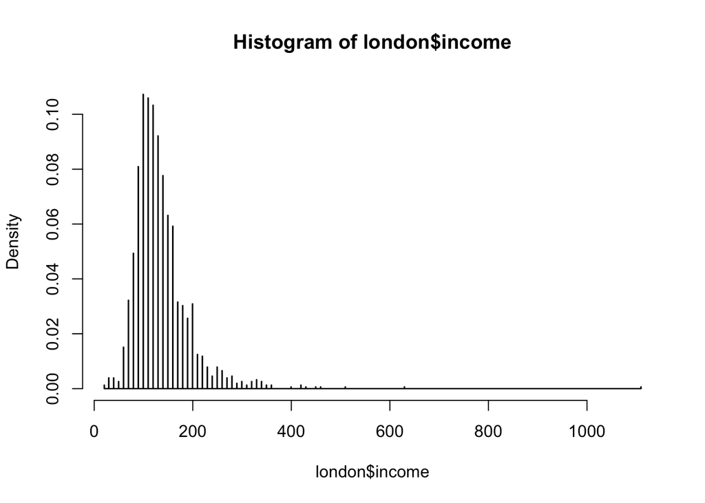

```r
hist(london$income,breaks=1000,freq = FALSE)
```

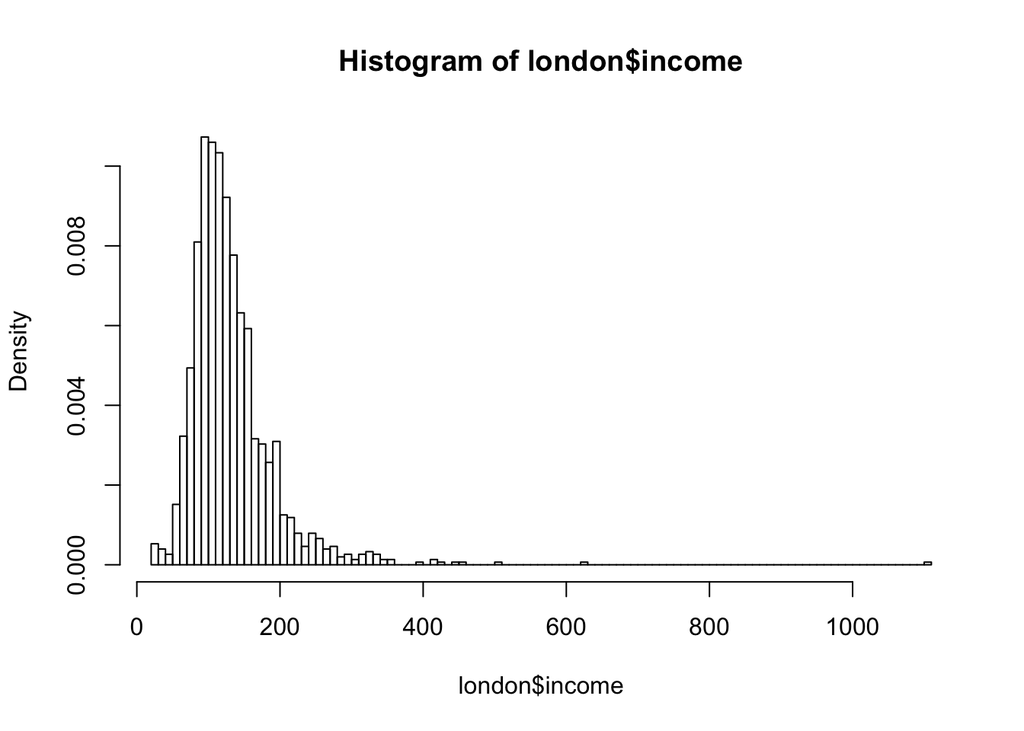

```r
hist(london$income,breaks=100,freq = FALSE)
```

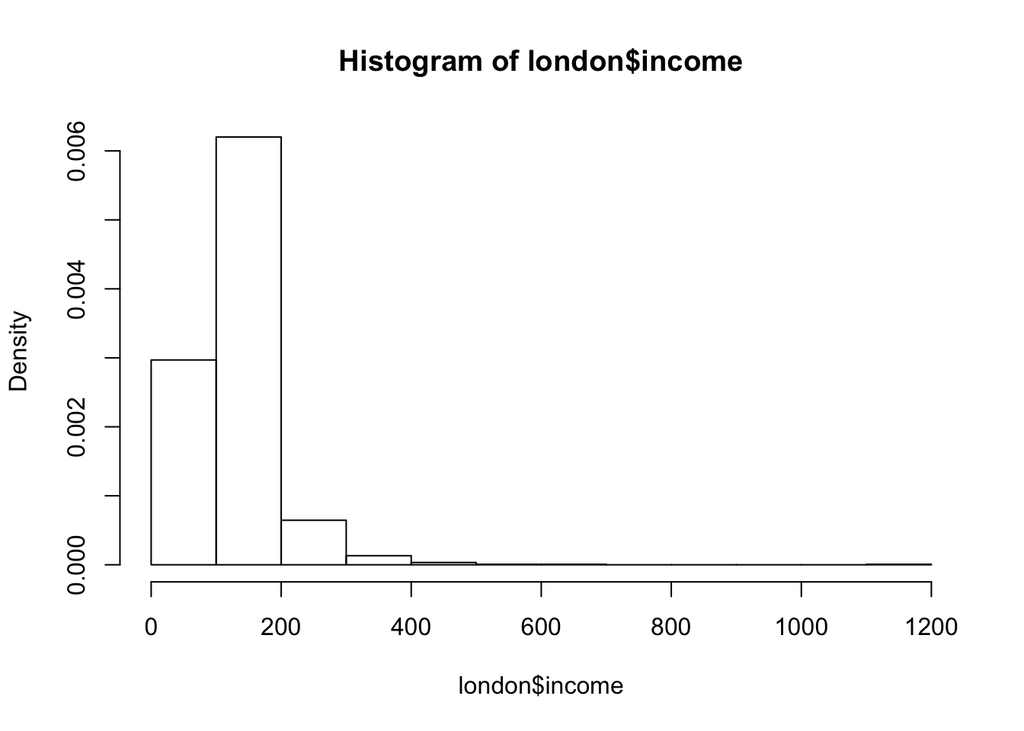

```r
hist(london$income,breaks=10,freq = FALSE)
```

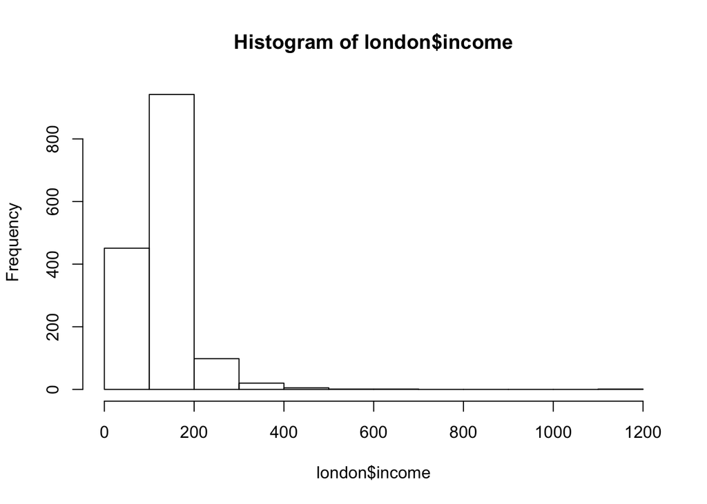

```r
hist(london$income,breaks=10,freq = TRUE)
```

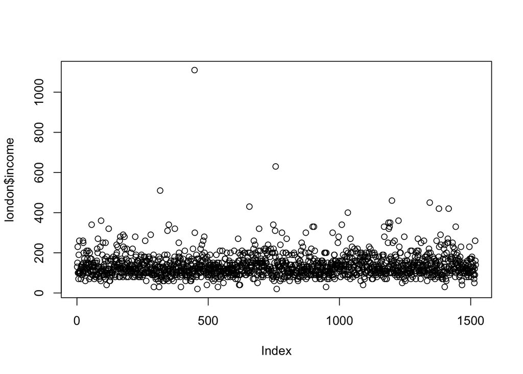

```r
plot(london$income)
```

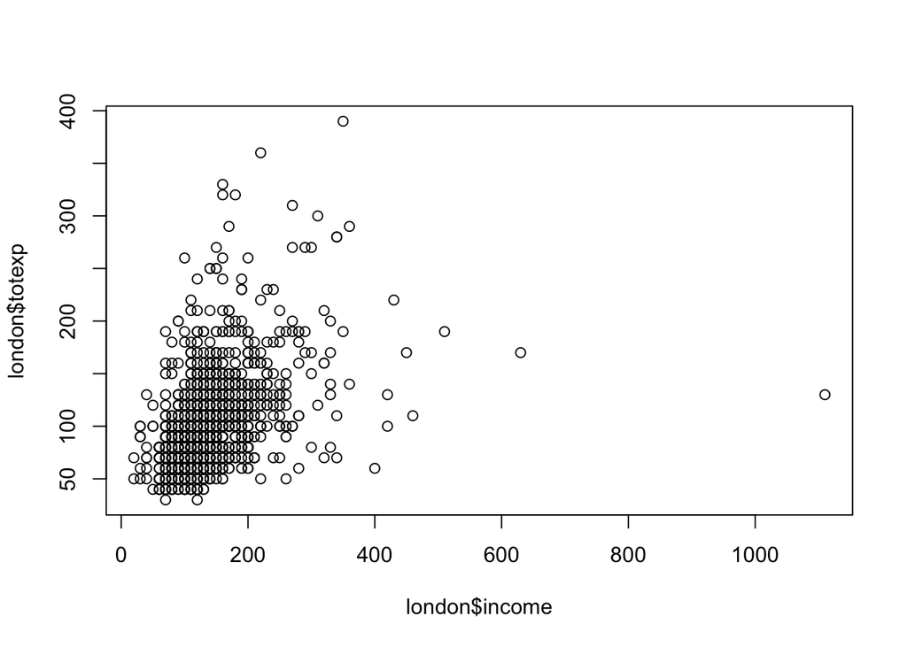

```r
plot(london$income,london$totexp)
```

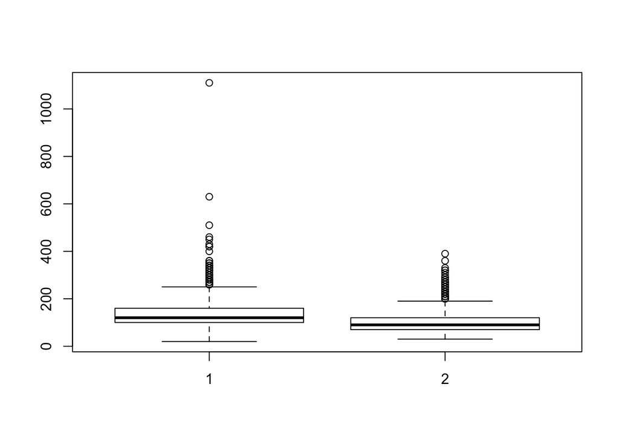

```r
boxplot(london$income,london$totexp)#draw a boxplot
```

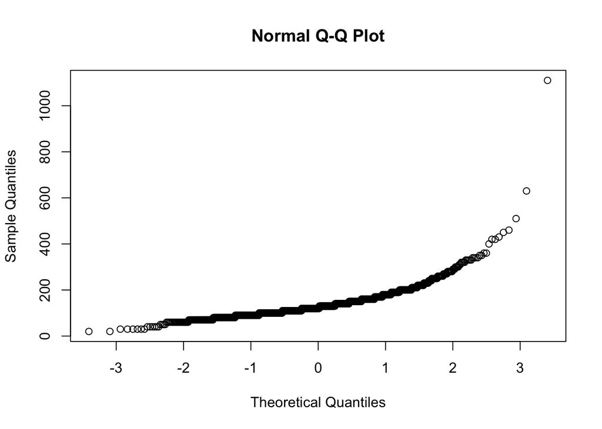

```r
qqnorm(london$income)#plot the qq-plot
```

```r
which(london$income>140)#return the indices for observations with income higher than 140.
```

```
##   [1]    2    3    7    9   23   24   25   26   28   34   36   37   40   43
##  [15]   44   49   51   55   56   62   69   75   76   77   79   80   89   92
##  [29]   97   99  106  107  109  114  119  121  130  131  138  145  147  148
##  [43]  150  151  152  155  161  163  165  169  170  172  173  176  177  181
##  [57]  182  184  188  190  192  197  206  209  212  222  224  225  228  230
##  [71]  233  234  238  244  246  248  255  258  259  260  262  265  268  273
##  [85]  274  276  277  281  283  289  292  310  312  315  317  325  334  340
##  [99]  344  345  350  353  355  358  369  372  373  374  384  386  387  388
## [113]  389  391  392  395  402  404  411  419  424  425  427  433  437  442
## [127]  447  448  449  453  455  458  463  471  472  476  478  479  481  482
## [141]  485  486  488  492  496  497  506  507  519  531  534  540  545  553
## [155]  554  564  565  571  580  582  585  592  599  611  614  615  616  619
## [169]  623  629  631  632  633  634  635  637  640  643  644  649  651  653
## [183]  657  658  659  666  668  669  670  672  673  674  678  679  680  681
## [197]  682  683  684  689  691  694  695  697  698  699  700  702  706  707
```

[output cut: 21 more lines]

```r
cov(london$income,london$totexp)# show the sample covariance between income and total expenditure.
```

```
## [1] 1183.511
```

```r
cor(london[,2:11])#sample correlation matrix for the 2-11 variables(columns) in london
```

```
##              wfood       wfuel wcloth walc       wtrans       wother
## wfood   1.00000000  0.10156032     NA   NA -0.333761601 -0.353580774
## wfuel   0.10156032  1.00000000     NA   NA -0.160910408 -0.132764775
## wcloth          NA          NA      1   NA           NA           NA
## walc            NA          NA     NA    1           NA           NA
## wtrans -0.33376160 -0.16091041     NA   NA  1.000000000 -0.295970628
## wother -0.35358077 -0.13276478     NA   NA -0.295970628  1.000000000
## totexp -0.47874726 -0.31937891     NA   NA  0.148271628  0.157614011
## income -0.23466674 -0.02870070     NA   NA  0.008442807  0.153370720
## age     0.02140373 -0.03951842     NA   NA  0.026928761  0.026064288
## nk      0.10178633 -0.02723013     NA   NA -0.043608816 -0.005305898
##             totexp       income          age           nk
## wfood  -0.47874726 -0.234666736  0.021403728  0.101786327
## wfuel  -0.31937891 -0.028700703 -0.039518424 -0.027230131
## wcloth          NA           NA           NA           NA
## walc            NA           NA           NA           NA
## wtrans  0.14827163  0.008442807  0.026928761 -0.043608816
## wother  0.15761401  0.153370720  0.026064288 -0.005305898
## totexp  1.00000000  0.448740348  0.189450718  0.071415282
## income  0.44874035  1.000000000  0.218494045  0.025439105
## age     0.18945072  0.218494045  1.000000000  0.008092095
## nk      0.07141528  0.025439105  0.008092095  1.000000000
```

```r
summary(london[,2:11])#summary some statistics for the 2-11 variables(columns) in london
```

```
##      wfood            wfuel             wcloth             walc
##  Min.   :0.0571   Min.   :0.00000   Min.   :0.00000   Min.   :0.00000
##  1st Qu.:0.2817   1st Qu.:0.05530   1st Qu.:0.03220   1st Qu.:0.01252
##  Median :0.3540   Median :0.08000   Median :0.08575   Median :0.04220
##  Mean   :0.3565   Mean   :0.09101   Mean   :0.10729   Mean   :0.06057
##  3rd Qu.:0.4258   3rd Qu.:0.11365   3rd Qu.:0.15827   3rd Qu.:0.08983
##  Max.   :0.7890   Max.   :0.48030   Max.   :0.76020   Max.   :0.42810
##                                     NA's   :1         NA's   :1
##      wtrans            wother           totexp          income
##  Min.   :0.00000   Min.   :0.0361   Min.   : 30.0   Min.   :  20.0
##  1st Qu.:0.05695   1st Qu.:0.1785   1st Qu.: 70.0   1st Qu.: 100.0
##  Median :0.11530   Median :0.2397   Median : 90.0   Median : 120.0
##  Mean   :0.13235   Mean   :0.2523   Mean   : 98.7   Mean   : 136.2
##  3rd Qu.:0.17940   3rd Qu.:0.3100   3rd Qu.:120.0   3rd Qu.: 160.0
##  Max.   :0.76380   Max.   :0.8066   Max.   :390.0   Max.   :1110.0
##
##       age              nk
##  Min.   :19.00   Min.   :1.000
##  1st Qu.:30.00   1st Qu.:1.000
##  Median :35.00   Median :2.000
##  Mean   :35.78   Mean   :1.609
##  3rd Qu.:40.00   3rd Qu.:2.000
##  Max.   :60.00   Max.   :2.000
##
```

```r
colSums(london[,2:11])# return the column sums of the 2-11 variables in
```

```
##       wfood       wfuel      wcloth        walc      wtrans      wother
##    541.4616    138.2480          NA          NA    201.0404    383.3165
##      totexp      income         age          nk
## 149920.0000 206960.0000  54348.0000   2444.0000
```

```r
#rowSums(london[2:11,])# return the row sums of the 2-11 rows in london
```

Question 1: Can you find out which variables have missing obervation(s)? in what positions?

**1st: use manual way to seek the missing data**

```r
#colSums(london)# 2 columns:wcloth and walc
#rowSums(london)# 2 rows: 10 and 15

london$wcloth[10]#NA
```

```
## [1] NA
```

```r
london$walc[15]#NA
```

```
## [1] NA
```

```r
is.na(london$wcloth[1:20])
```

```
##  [1] FALSE FALSE FALSE FALSE FALSE FALSE FALSE FALSE FALSE  TRUE FALSE
## [12] FALSE FALSE FALSE FALSE FALSE FALSE FALSE FALSE FALSE
```

**2rd: use auto way to seek the missing data**

```r
setwd("/Users/sn0wfree/Dropbox/PhD_1st_study/BST169_Econometrics/Computing/session1-5")#setup the working directory
london<-read.csv('london.csv')# import data from london.csv

compare_missing_data_function<-function(symbol){
  b<-c()
  for (i in 1:length(symbol)){
    if(is.na(symbol[i])==TRUE){
      b=append(b,i)
    }
  }
  return(b)
}

seek_missing_data<- function(data){
  missing_data_location<-c()
  missing_col_number<-compare_missing_data_function(colSums(data))
  missing_row_number<-compare_missing_data_function(rowSums(data))
  for(i in missing_col_number){
    for(j in missing_row_number){
      if (is.na(data[j,i])==TRUE){
        missing_data_location<-append(missing_data_location,c(names(data)[i],j))}
      }
  }
  return(missing_data_location)
}

seek_missing_data(london)
```

```
## [1] "wcloth" "10"     "walc"   "15"
```

## Least Squares Regression

### OLS

```r
lmobj<-lm(wfood~log(totexp)+log(income),data=london)
summary(lmobj)#summary of the fitted model
```

```
##
## Call:
## lm(formula = wfood ~ log(totexp) + log(income), data = london)
##
## Residuals:
##      Min       1Q   Median       3Q      Max
## -0.33339 -0.06201 -0.00229  0.06075  0.32267
##
## Coefficients:
##              Estimate Std. Error t value Pr(>|t|)
## (Intercept)  0.964691   0.033414  28.871   <2e-16 ***
## log(totexp) -0.133104   0.006924 -19.224   <2e-16 ***
## log(income) -0.001564   0.007142  -0.219    0.827
## ---
## Signif. codes:  0 '***' 0.001 '**' 0.01 '*' 0.05 '.' 0.1 ' ' 1
##
## Residual standard error: 0.09139 on 1516 degrees of freedom
## Multiple R-squared:  0.2452, Adjusted R-squared:  0.2442
## F-statistic: 246.2 on 2 and 1516 DF,  p-value: < 2.2e-16
```

```r
typeof(lmobj)# is a list
```

```
## [1] "list"
```

```r
class(lmobj)# is a "lm"
```

```
## [1] "lm"
```

`typeof(lmobj)` and `class(lmobj)` have different return value

```r
coef(lmobj)#estimated model parameters (estimated_beta of OLS)
```

```
##  (Intercept)  log(totexp)  log(income)
##  0.964691151 -0.133104065 -0.001564379
```

```r
head(resid(lmobj)) #estimated residuals M_{x,y}
```

```
##            1            2            3            4            5
## -0.009170321  0.015990337 -0.070880272  0.069578635 -0.025443964
##            6
## -0.017352911
```

```r
head(fitted(lmobj)) #fitted values of the model (P_{x,y})
```

```
##         1         2         3         4         5         6
## 0.4363703 0.3579097 0.2649803 0.3742214 0.3585440 0.3925529
```

```r
deviance(lmobj) #the residual sum of squares (SSR or y'M_{x,y})
```

```
## [1] 12.66322
```

```r
confint(lmobj) #confidence interval
```

```
##                   2.5 %      97.5 %
## (Intercept)  0.89914931  1.03023299
## log(totexp) -0.14668549 -0.11952264
## log(income) -0.01557339  0.01244463
```

```r
logLik(lmobj) #value of the log likelihood function (assume normal er- ror)
```

```
## 'log Lik.' 1480.439 (df=4)
```

```r
AIC(lmobj,k=2) #information criterion, k = 2 for AIC and k = log(N) for BIC (assume normal error, to be covered later)
```

```
## [1] -2952.879
```

```r
vcov(lmobj)# estimated-beta OLS’s estimated variance-covariance matrix (\espison^{hat}_{2}(X'X)_{-1})
```

```
##               (Intercept)   log(totexp)   log(income)
## (Intercept)  1.116471e-03 -9.885454e-05 -1.373587e-04
## log(totexp) -9.885454e-05  4.794031e-05 -2.427202e-05
## log(income) -1.373587e-04 -2.427202e-05  5.100646e-05
```

```r
anova(lmobj) #returns an anova table; ANOVA analysis
```

```
## Analysis of Variance Table
##
## Response: wfood
##               Df  Sum Sq Mean Sq F value Pr(>F)
## log(totexp)    1  4.1123  4.1123 492.315 <2e-16 ***
## log(income)    1  0.0004  0.0004   0.048 0.8266
## Residuals   1516 12.6632  0.0084
## ---
## Signif. codes:  0 '***' 0.001 '**' 0.01 '*' 0.05 '.' 0.1 ' ' 1
```

```r
predict(lmobj,data.frame(totexp=1,income=1)) #returns predictions
```

```
##         1
## 0.9646912
```

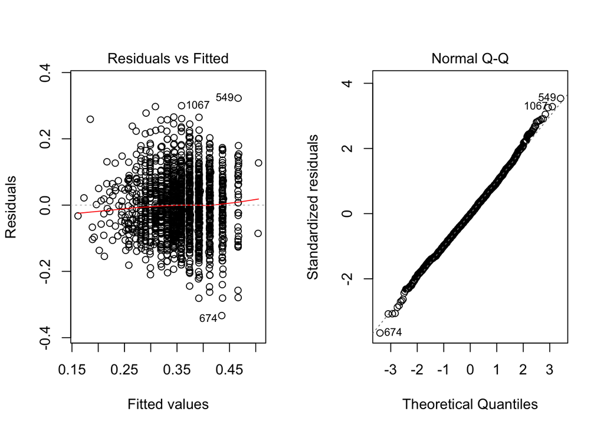

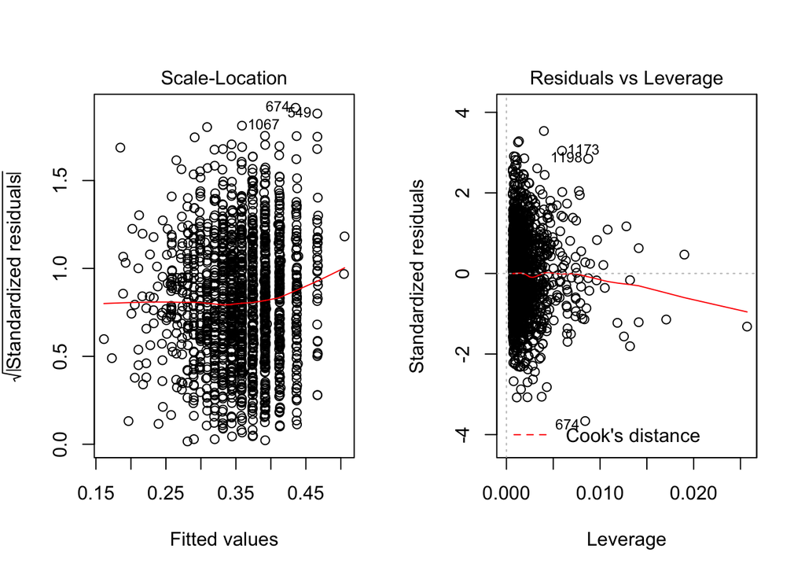

```r
par(mfrow=c(1,2))#par graphes by 2*2
plot(lmobj) #create diagnostic plots
```

```r
par(mfrow=c(1,1))#restore the default one
```

Question 2: Can you use matrix algebra in R to reproduce the outputs of the following functions:

because the matrix form can be easy solved out thus, i show the solution of this OLS methods:

the OLS mainly aims to solve the $\beta$, based on the minimum of Sum Squared Residuals(SSR):

and minimize the SSR

that is the solution of beta from OLS methods

```r
x<-cbind(rep(1,length(london$wfood)),log(london$totexp),log(london$income))# create the martix x in the equation (1)
coef_of_lmboj<-solve(t(x)%*%x)%*%t(x)%*%london$wfood#coef(lmobj)
coef(lmobj)
```

```
##  (Intercept)  log(totexp)  log(income)
##  0.964691151 -0.133104065 -0.001564379
```

```r
coef_of_lmboj
```

```
##              [,1]
## [1,]  0.964691151
## [2,] -0.133104065
## [3,] -0.001564379
```

```r
fitted_of_lmobj<-x%*%coef_of_lmboj#fitted(lmobj)
head(fitted(lmobj))
```

```
##         1         2         3         4         5         6
## 0.4363703 0.3579097 0.2649803 0.3742214 0.3585440 0.3925529
```

```r
head(fitted_of_lmobj)
```

```
##           [,1]
## [1,] 0.4363703
## [2,] 0.3579097
## [3,] 0.2649803
## [4,] 0.3742214
## [5,] 0.3585440
## [6,] 0.3925529
```

```r
resid_of_lmobj<-london$wfood-x%*%coef_of_lmboj#resid(lmobj)
head(resid(lmobj))
```

```
##            1            2            3            4            5
## -0.009170321  0.015990337 -0.070880272  0.069578635 -0.025443964
##            6
## -0.017352911
```

```r
head(resid_of_lmobj)
```

```
##              [,1]
## [1,] -0.009170321
## [2,]  0.015990337
## [3,] -0.070880272
## [4,]  0.069578635
## [5,] -0.025443964
## [6,] -0.017352911
```

```r
deviance_of_lmobj<-t(resid_of_lmobj)%*%resid_of_lmobj#just calulate the SSR,equal to deviance(lmobj)
head(deviance(lmobj))
```

```
## [1] 12.66322
```

```r
head(deviance_of_lmobj)
```

```
##          [,1]
## [1,] 12.66322
```

```r
vcov(lmobj)
```

```
##               (Intercept)   log(totexp)   log(income)
## (Intercept)  1.116471e-03 -9.885454e-05 -1.373587e-04
## log(totexp) -9.885454e-05  4.794031e-05 -2.427202e-05
## log(income) -1.373587e-04 -2.427202e-05  5.100646e-05
```